# Regresja liniowa i wieloraka - projekt

### Normalność reszt

Sprawdźmy normalność naszych reszt:

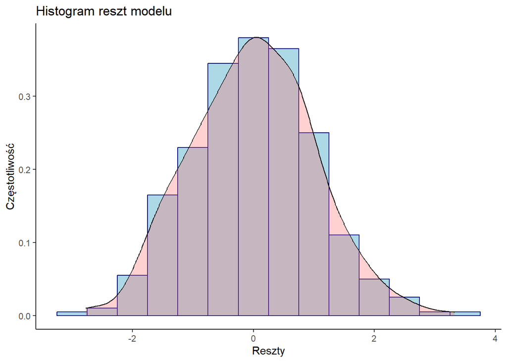

```r
ggplot(new_lmfit2, aes(x=resid(new_lmfit2)))+
  labs(title = 'Histogram reszt modelu',
       x = 'Reszty',
       y = 'Częstotliwość') +
  geom_histogram(aes(y=..density..),
                 color="darkblue",
                 fill="lightblue",
                 binwidth = 0.5) +
  geom_density(alpha=.3, fill="#FF6666") +
  theme_classic()
```

Reszty w naszym modelu wydają się być zbliżone do rozkładu normalnego, natomiast nie możemy tego stwierdzić w 100%. Sprawdźmy wykres `QQ-plot` do zbadania rozkładu normalnego naszych zmiennych.

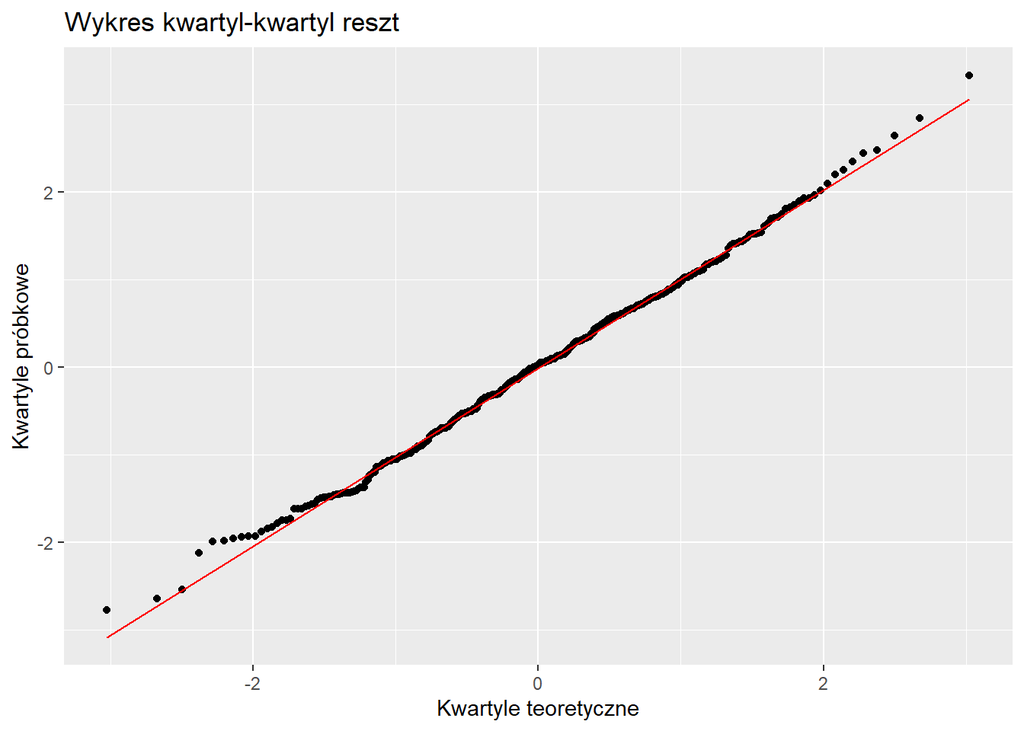

```r
ggplot(new_lmfit2, aes(sample=new_lmfit2$residuals)) +
  geom_qq() +
  geom_qq_line(color = 'red') +
  labs(title='Wykres kwartyl-kwartyl reszt', x='Kwartyle teoretyczne', y='Kwartyle próbkowe')
```

Widzimy, że prawie wszystkie punkty leżą na czerwonej lini, jedynie problem jest na początku oraz na końcu.

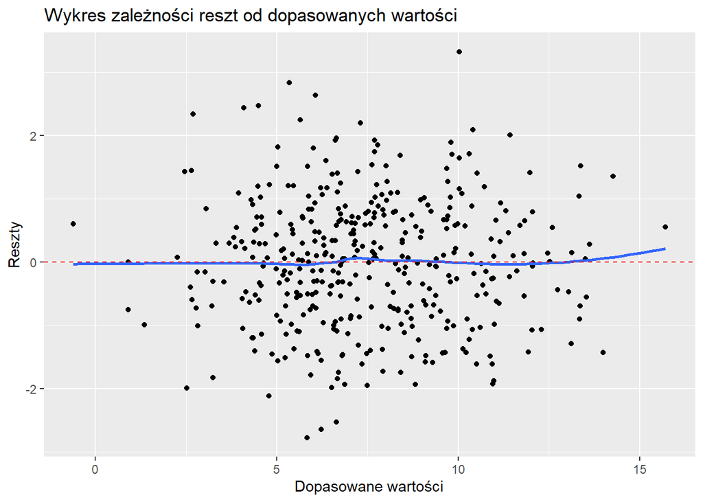

```r
new_lmfit2 %>%
ggplot(aes(.fitted, .resid)) +
  geom_point() +
  stat_smooth(method='loess', formula=y~x, se=F) +
  geom_hline(yintercept=0, linetype='dashed', color='red') +
  labs(title='Wykres zależności reszt od dopasowanych wartości',
       x='Dopasowane wartości',
       y='Reszty')
```

Na wykresie zależności reszt od dopasowanych wartości możemy zauważyć delikatne odchylenie w końcowej jego fazie. Innymi słowy, współczynniki modelu regresji powinny być godne zaufania i nie musimy wykonywać transformacji na danych.